# *Ensemble Learning - Machine Learning Concept*

## *Regression Model - Insurance HealthCare Costs*

```python
dataset_regression = pd.read_csv(r'C:\Users\PiyushSin\Desktop\datasets\insurance.csv')
dataset_regression.head()
```

|  | age | sex | bmi | children | smoker | region | charges |
| --- | --- | --- | --- | --- | --- | --- | --- |
| 0 | 19 | female | 27.900 | 0 | yes | southwest | 16884.92400 |
| 1 | 18 | male | 33.770 | 1 | no | southeast | 1725.55230 |
| 2 | 28 | male | 33.000 | 3 | no | southeast | 4449.46200 |
| 3 | 33 | male | 22.705 | 0 | no | northwest | 21984.47061 |
| 4 | 32 | male | 28.880 | 0 | no | northwest | 3866.85520 |

```python
# check for missing values
missing_values = dataset_regression.isnull().sum().sort_values(ascending = False)
missing_values = missing_values[missing_values > 0]/dataset_regression.shape[0] # normalize
print(f'{missing_values *100} %')
```

```
Series([], dtype: float64) %
```

```python
from sklearn.preprocessing import LabelEncoder

# convert str values to int using the scikit-learn encoder
st = dataset_regression.apply(LabelEncoder().fit_transform)
st.head()
```

|  | age | sex | bmi | children | smoker | region | charges |
| --- | --- | --- | --- | --- | --- | --- | --- |
| 0 | 1 | 0 | 197 | 0 | 1 | 3 | 1005 |
| 1 | 0 | 1 | 350 | 1 | 0 | 2 | 57 |
| 2 | 10 | 1 | 331 | 3 | 0 | 2 | 306 |
| 3 | 15 | 1 | 73 | 0 | 0 | 1 | 1097 |
| 4 | 14 | 1 | 223 | 0 | 0 | 1 | 254 |

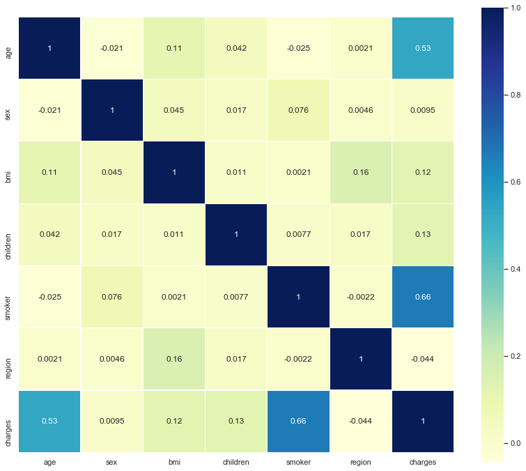

```python
sns.set(color_codes=True)
plt.figure(figsize=(14, 12))
sns.heatmap(st.astype(float).corr(),
            linewidths=0.2,
            square=True,
            linecolor='white',
            annot=True,
            cmap="YlGnBu")
plt.show()
```

*Seems like age and smoking weigh the most when looking at the charges row (or column). We expect the weights of these two to be higher than the rest.*

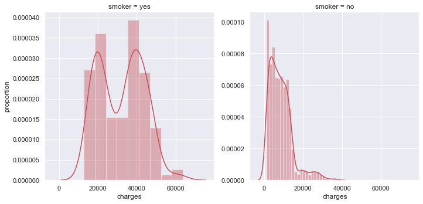

```python
g = sns.FacetGrid(dataset_regression, col="smoker",  size= 5, sharey=False, sharex = True)
g.map(sns.distplot, "charges", color = 'r');
g.set_axis_labels("charges", "proportion");
g.despine(left=True)
```

*No surprise that smokers pay more for healtcare.*

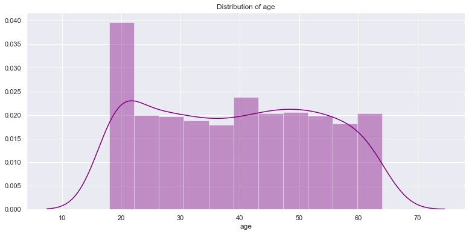

```python
plt.figure(figsize=(13,6))
plt.title("Distribution of age")
ax = sns.distplot(dataset_regression["age"], color = 'purple')
```

*Judging by the party life at UVa, we can see why so many young adults even seek medical care.*

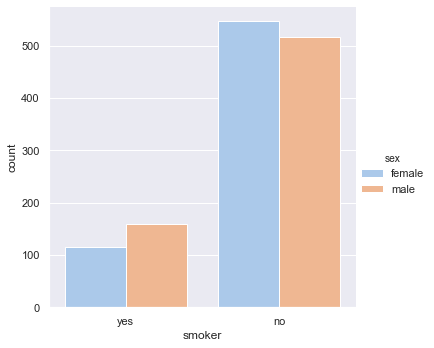

```python
sns.catplot(x="smoker", kind="count", hue = 'sex', data = dataset_regression , palette='pastel');
plt.show()
```

*Luckily, the majority understands the downsides of smoking.*

*The data seems pretty balanced with a slight skew towards male.*

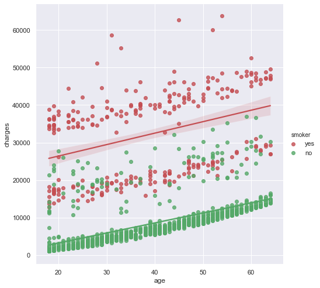

```python
sns.lmplot(x="age", y="charges", hue="smoker", data=dataset_regression, palette=dict(yes="r", no="g"), size = 7);
ax.set_title('Smokers and non-smokers');
plt.show()
```

*While it seems obvious that the charges increase linearly with age, smoking appears to be the highest contributor to charges.*

```python
df = dataset_regression.copy()

df['age'] = df['age'].astype(float)
df['children'] = df['children'].astype(float)

df = pd.get_dummies(df)

df.head()
```

|  | age | bmi | children | charges | sex_female | sex_male | smoker_no | smoker_yes | region_northeast | region_northwest | region_southeast | region_southwest |
| --- | --- | --- | --- | --- | --- | --- | --- | --- | --- | --- | --- | --- |
| 0 | 19.0 | 27.900 | 0.0 | 16884.92400 | 1 | 0 | 0 | 1 | 0 | 0 | 0 | 1 |
| 1 | 18.0 | 33.770 | 1.0 | 1725.55230 | 0 | 1 | 1 | 0 | 0 | 0 | 1 | 0 |
| 2 | 28.0 | 33.000 | 3.0 | 4449.46200 | 0 | 1 | 1 | 0 | 0 | 0 | 1 | 0 |
| 3 | 33.0 | 22.705 | 0.0 | 21984.47061 | 0 | 1 | 1 | 0 | 0 | 1 | 0 | 0 |
| 4 | 32.0 | 28.880 | 0.0 | 3866.85520 | 0 | 1 | 1 | 0 | 0 | 1 | 0 | 0 |

```python
y = df['charges']
X = df.drop(columns=['charges'])
```

```python
# use 10% of dataset as testing data

X_train, X_test, y_train, y_test = train_test_split(
    X, y, test_size=0.1, random_state=42)
```

```python
from sklearn.ensemble import RandomForestRegressor
from sklearn.metrics import mean_squared_error, r2_score

rfr = RandomForestRegressor(n_estimators = 50).fit(X_train, y_train)

rfr_train_pred = rfr.predict(X_train)
rfr_test_pred = rfr.predict(X_test)


rfr_train_mse = mean_squared_error(y_train,rfr_train_pred)
rfr_test_mse = mean_squared_error(y_test,rfr_test_pred)


print('MSE train data: {:.5}, MSE test data: {:.5}'.format(rfr_train_mse, rfr_test_mse))

print('RMSE train data: {:.5}, RMSE test data: {:.5}'.format(
    np.sqrt(np.absolute(rfr_train_mse)),
    np.sqrt(np.absolute(rfr_train_mse))))

print('R2 train data: {:.5}, R2 test data: {:.5}'.format(
    r2_score(y_train, rfr_train_pred),
    r2_score(y_test, rfr_test_pred)))
```

[output not shown]

```python
rfr_cv = cross_val_score(rfr, X_train, y_train, cv = 7)
# accuracy +/- 2 standard deviations
print("Accuracy: {:.2} (+/- {:.2})".format(rfr_cv.mean(), rfr_cv.std() * 2))
```

```
Accuracy: 0.83 (+/- 0.073)
```

```python
rfr.predict(X_test)
```

```
array([10230.1183974 ,  5249.3232556 , 28766.662484  , 10995.8168624 ,
       34856.1367918 ,  8157.5937874 ,  2121.427068  , 15062.25728   ,
        6986.9005004 , 12147.9559278 , 18539.5149762 ,  7437.5256018 ,
        5759.4039756 , 45239.4153734 , 48520.730494  , 44894.4329164 ,
        9668.561361  , 43332.9723454 ,  8781.232808  , 27519.8392174 ,
        4499.531112  ,  9135.2838914 ,  1393.852409  ,  2736.459614  ,
       12922.8699426 , 10774.899656  , 13638.7108116 ,  5235.8588686 ,
       10378.9416742 ,  4171.43597015,  7693.842721  , 11876.625694  ,
        2767.054977  ,  5414.0698552 ,  4006.545666  , 11143.829091  ,
        2733.3936566 ,  8668.3027492 , 23714.917532  , 39116.576313  ,
        7493.5062368 ,  3282.8940258 , 12337.476713  , 14829.4079822 ,
        5933.7492334 , 13892.5482844 , 18994.5160698 ,  5595.0266342 ,
       41705.4856462 ,  6817.703615  , 13738.647611  ,  2329.77583018,
        6945.3649116 ,  1723.128886  , 13703.9142276 ,  9726.433285  ,
        4065.8745702 , 40331.242678  , 12100.2170274 , 12798.5555122 ,
       13684.218036  ,  5312.3355862 , 19795.9231876 ,  7383.565473  ,
       10271.8058626 ,  4993.483359  , 16876.6304546 , 15208.0522248 ,
        7466.4167216 ,  2451.214811  ,  6777.6765768 , 10477.3909874 ,
        9006.5361922 , 10490.48428   ,  7705.5170796 ,  5068.7477736 ,
        6335.048739  , 12753.379874  ,  6701.7233594 , 10455.264222  ,
        1891.716301  , 28921.9403774 ,  6452.863782  , 37298.1585734 ,
       40898.6135488 , 41538.388735  ,  4846.126999  , 11821.5255284 ,
        8867.1724612 , 13188.6897944 , 20675.712143  , 27033.597748  ,
       28771.9081022 ,  5867.5085402 , 41805.7023666 ,  7078.1268494 ,
       19690.356424  ,  2891.954181  , 18188.1713844 , 13279.2927324 ,
        4908.513899  ,  1792.58741   ,  6078.7214406 , 14419.5637174 ,
       13401.3741362 ,  7428.309689  ,  9370.1927408 , 23936.93328   ,
        1701.561186  , 24029.8818412 ,  1291.02486   ,  3170.0375234 ,
       13030.8393934 , 38373.5184466 , 11704.2345442 ,  6731.6564644 ,
       12531.808309  , 28059.221547  ,  7831.0666384 ,  7461.0770144 ,
        7443.422264  ,  8730.8478274 , 18960.8212712 ,  2803.1278202 ,
        6969.788883  ,  7566.9888154 , 12376.0225534 , 12605.7630268 ,
       15560.1217084 ,  5171.4004244 ,  4011.391652  ,  6804.9682082 ,
        6312.0314902 , 12891.4831526 ])
```

## *Hyperparameters in Random Forest*

*The hyperparameters in random forest are either used to increase the predictive power of the model or to make the model faster. Let's look at the hyperparameters of sklearns built-in random forest function.*

### *Increasing the predictive power*

_Firstly, there is the **n_estimators** hyperparameter, which is just the number of trees the algorithm builds before taking the maximum voting or taking the averages of predictions. In general, a higher number of trees increases the performance and makes the predictions more stable, but it also slows down the computation._

_Another important hyperparameter is **max_features**, which is the maximum number of features random forest considers to split a node._

_The last important hyperparameter is **min_sample_leaf**. This determines the minimum number of leafs required to split an internal node._

### *Increasing the model's speed*

_The **n_jobs** hyperparameter tells the engine how many processors it is allowed to use. If it has a value of one, it can only use one processor. A value of “-1” means that there is no limit._

_The **random_state** hyperparameter makes the model’s output replicable. The model will always produce the same results when it has a definite value of random*state and if it has been given the same hyperparameters and the same training data.*

_Lastly, there is the **oob_score** (also called oob sampling), which is a random forest cross-validation method. In this sampling, **about one-third of the data is not used to train the model and can be used to evaluate its performance**. These samples are called the out-of-bag samples. It's very similar to the leave-one-out-cross-validation method, but almost no additional computational burden goes along with it._

## *Advantages*

- *Reduction in overfitting*: *by averaging several trees, there is a significantly lower risk of overfitting.*
- *It is very easy to measure the relative importance of each feature on the prediction. **Feature importance matrix** provides a nice way to start getting insights about the data.*
- *It has few, if any, statistical assumptions. It does not assume that your data is normally distributed, the relationship is linear, or you have specified interactions.*
- *Can be used for both regression and classification tasks*
- *Random forests can also handle missing values. There are two ways to handle these: using median values to replace continuous variables, and computing the proximity-weighted average of missing values. Prior to splitting a node, missing data for a variable is imputed by randomly drawing values from non-missing in-bag data.*
- *It is robust to outliers.*
- *It has an in-built validation mechanism named Out-of-bag (OOB) score.*

## *Disadvantages*

- *It’s more complex and computationally expensive than decision tree algorithm. Fact which makes the algorithm slow and ineffective for real-time predictions as a more accurate prediction requires more trees.*
- *The downside of methods like random forest or any other bagging algorithms is their non interpret-ability.*